# A Study on the Link between Several Measures from the Turkish Housing Market

Nilüfer Çetin - IE360 - Fall 2020

30 11 2020

# Introduction

Over the last few years in Turkey, it is frequently mentioned that the housing and construction has become an important sector that is used to support the fragile economy. There are a lot of undergoing mass housing projects that are aimed to target various potential buyers. Moreover, people nowadays usually do not own a house just for accommodation; investment, seasonal tourism and renting has become popular reasons for people to buy residences. Although there is an ever increasing number of housing projects and potential customers, it is not sensible to think that all of these customers have the enough amount of money to fund this transaction. In fact, taking out a loan from a bank is a widely used way to buy any kind of housing. This loan is usually referred to as “housing credit”.

Of course the banks do not give the housing credit right away. There are several procedures such as inspection of the house of interest, analysis of economic situation and assets of the customer etc. Once the credit is taken, the bank applies an interest rate on the back payment of principal. The plan to pay the principal back can be divided into different time durations and the interest rate upon each payment can be announced using these durations such as monthly, quarterly and annually. The interest rates that the banks specify are dependent on various factors such as the inflation rate, exchange rates or country’s economic decisions. Nevertheless, the mechanics behind the determination of interest rates on housing credits are very complicated and are well beyond the scope of this work.

Although it is extremely hard for a regular citizen without a specific interest or education related to economy to understand how the interest rates on credits are computed, it is almost natural for anybody to look at the interest rates while deciding on whether or how much to take loan from a bank. As there are a lot of people using housing credit to buy residences, it is logical to assume that the interest rate applied on the housing credits may affect the funding preference of house buyers. Consequently, it can be claimed that the amount of housing credits taken can be somehow correlated with the interest rate on that specific period. Moreover, as there are not many choices to fund such an expensive asset, housing, whether or not a person is able to get a loan can directly affect a person’s decision to buy a house. As a result, it can be suggested that number of houses sold in a period can be predicted or indicated by the amount of housing credits taken which can also closely be related with the rate of interest on pay back. The research question this study aims to find out can be stated as “Are there any correlation, or to what extent, between number of houses sold, the total amount of housing credits taken and the interest rate applied on those credits on Turkey?”

To find an answer to the question of interest, data related to several measures from Turkey over a specific period will be analyzed. In the next part of this study, several different data visualization techniques as well as correlation analyses will be used. These visualizations and analyses will be conducted using different combinations of measures over different time periods or horizons. Therefore, a number of data manipulation techniques will be used as this is one of the main objectives of the study.

The data is taken from Electronic Data Delivery System on [EVDS](https://evds2.tcmb.gov.tr/). It is assumed that a period from January 2014 till September 2020 can be long enough to offer a solid analysis. Furthermore, these consecutive years are selected so that it should be easier to explain outlier values or unexpected phenomena since they will be up-to-date from both the researcher’s and reader’s perspective. The data taken are gathered in a monthly fashion. Secondly, there are three different measures of datasets. In one of the datasets, the total number of houses sold all over Turkey in a specific month is stated. In the other dataset, the total amount of housing credits in million TLs in a specific month are listed. These are the credits that are taken from Deposit Banks. Though there are other types of banks lending housing credit they do this in relatively very small amounts so it can easily be assumed that addition of these amounts might not make any difference in the analysis. The last dataset covers the interest rate on housing credits in Turkey month by month.

# Analysis

## Manipulation of Data

Before the analysis, it is necessary to manipulate the data in a more understandable and easy to work format. Since the data are taken from the same web page, they are more or less in very similar forms. Although there are a few extra manipulations, most of the data is manipulated using this function, for more detailed information the reader can take a look at the rmd file provided in the appendices.

```r
manipulator = function(x, type){
  x = as.data.table(x)
  x = x[1:83,1:2]
  x[,2] = as.numeric(unlist(x[,2]))
  x = x[, 1 := ymd(paste0(unlist(x[,1]), "-15"))]
  x = x[Tarih < "2020-10-15"]
  colnames(x) = c("Date", "Amount")
  if(type == "Credit"){
    x[,2] = x[,2]/1000
  }
  x$Type = rep(type)
  return (x)
}

amountSold = manipulator(read_xlsx("C:/Users/ŞAHİN ÇETİN/Desktop/KonutSatis.xlsx"), "Sold")
```

```
## * `` -> ...3
```

```r
creditsTaken = manipulator(read_xlsx("C:/Users/ŞAHİN ÇETİN/Desktop/KonutKredi.xlsx"), "Credit")
```

```
## * `` -> ...3
```

```r
interestonCredit = manipulator(read_xlsx("C:/Users/ŞAHİN ÇETİN/Desktop/KonutKrediFaiz.xlsx"), "Interest")
```

```
## * `` -> ...3
```

```r
allCombined = rbind(amountSold, creditsTaken, interestonCredit)
```

After the necessary operations, one of the dataset can be viewed, the others are very much similar. It should also be noted that the addition of the day component has become a need to facilitate the visualization of the time series data. For the rest of this study, it is kindly requested from the reader to think of the 15th day of a month as a representation of the whole monthly data.

```
##           Date Amount Type
##  1: 2014-01-15  87639 Sold
##  2: 2014-02-15  82597 Sold
##  3: 2014-03-15  87617 Sold
##  4: 2014-04-15  83610 Sold
##  5: 2014-05-15  90377 Sold
##  6: 2014-06-15  92936 Sold
##  7: 2014-07-15  85101 Sold
##  8: 2014-08-15 105624 Sold
##  9: 2014-09-15 115786 Sold
## 10: 2014-10-15  95645 Sold
```

There is also a bigger dataset combining all values with their respective dates. In this dataset the type column refers to the original measure of the amount. This is also created to provide a better visualization of the data.

```
## Classes 'data.table' and 'data.frame':   243 obs. of  3 variables:
##  $ Date  : Date, format: "2014-01-15" "2014-02-15" ...
##  $ Amount: num  87639 82597 87617 83610 90377 ...
##  $ Type  : chr  "Sold" "Sold" "Sold" "Sold" ...
##  - attr(*, ".internal.selfref")=<externalptr>
```

## Visual Analysis of Data

After those manipulations, it would be useful to visualize the measures in histogram to check for any assumption related to distribution or other statistics. To serve this purpose, year by year histograms of measures constituting of 12 different reported values is chosen as an appropriate format.

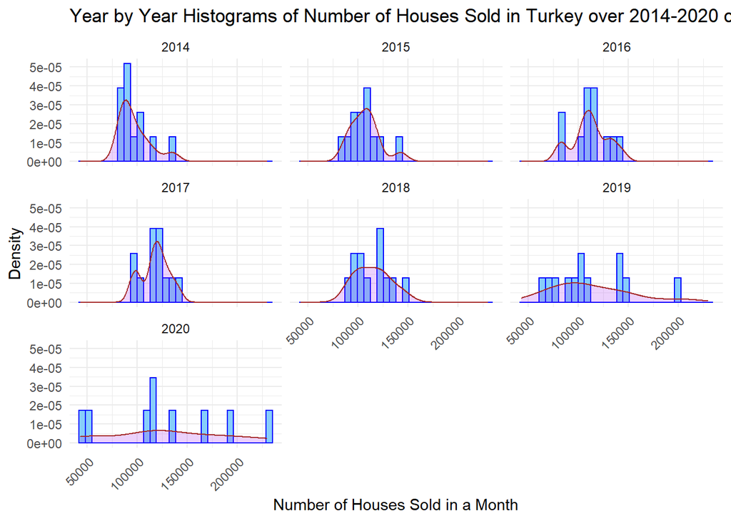

As can be seen from the plot, between years 2014 till 2019, the monthly number of houses sold can be somehow fitted into a normal distribution. Some of these plots are skewed and there mean values and variances do seem to fluctuate over the years. However, the samples along with their related statistics do not seem to drag into a specific direction over time. In the last two years, the variance is higher and the monthly number of houses sold seem to scatter into both directions. This major difference in the samples should be analyzed with the help of coming visualizations and tests.

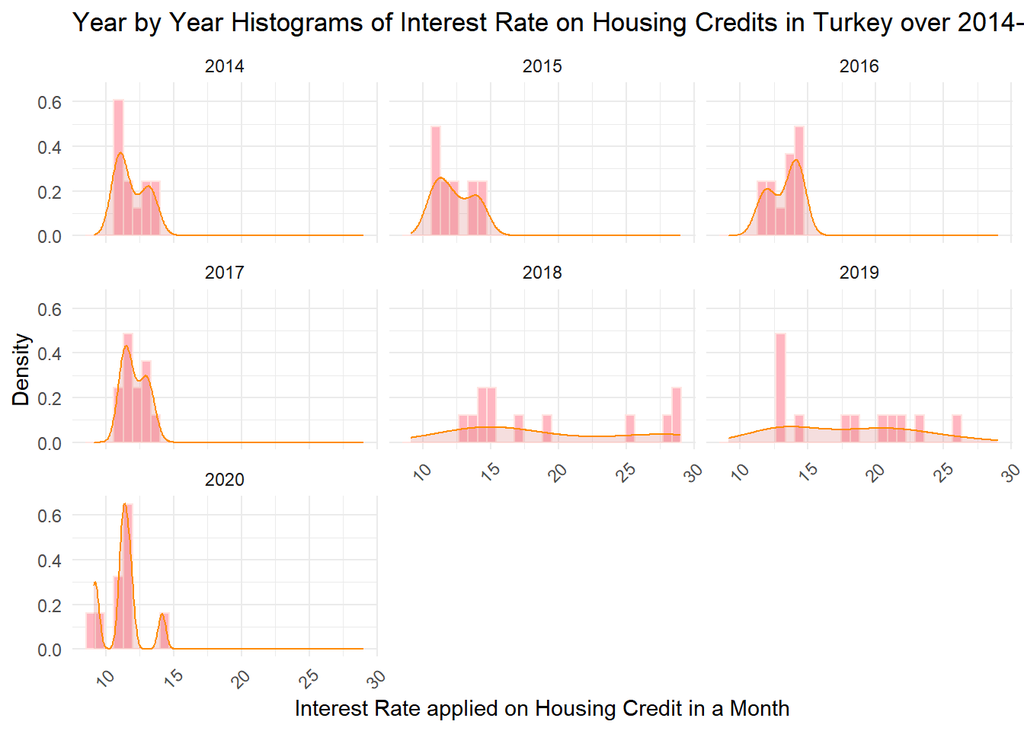

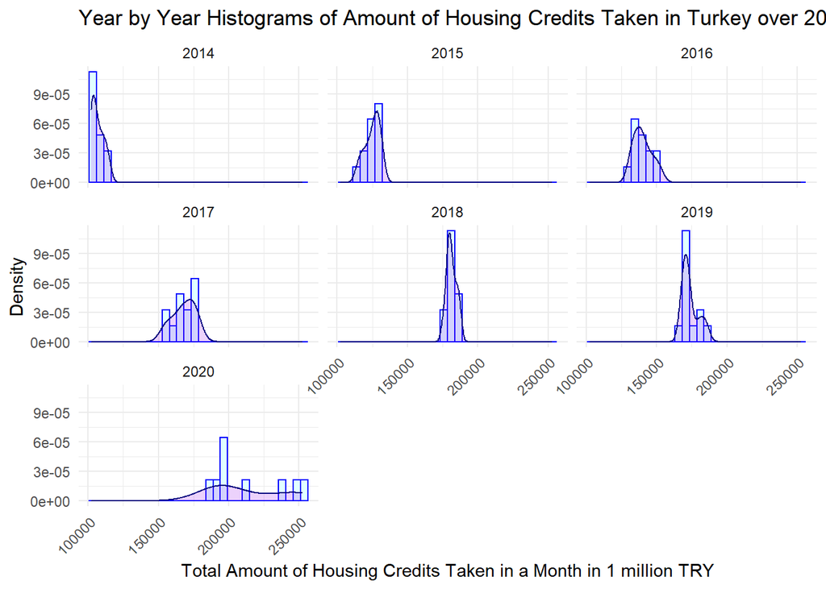

The year by year histograms of total amount of housing credits taken (in million TRYs) in a month seem to be revealing a trend. As opposed to the previous measures, the amount of housing credits taken can almost always be represented via a normal distribution, except this year 2020. However, the mean values are subject to a considerable increase. Furthermore, the monthly reported values in 2018 and 2019 are very much closer to each other compared to previous years. Although the assumption of normality still holds, this pattern along with the rule breaker 2020, should be inspected in detail.

By those plotted histograms, it is evident that there is an increasing trend in amount of credits. More importantly, in the last three years there are unexpected behaviors regarding all of the measures. Before jumping into conclusions, incorporating a more detailed time dimension should be useful.

After these steps, the data over January 2014 – September 2020 can be plotted. In the next plot, the total number of houses sold and the total amounts of credit taken in million TLs are represented by lines. The choice of million as a multiplier is to provide an effective demonstration of these two measures using the same scale. Also, in the upcoming plot the interest rate is visualized using a bar plot so that the reader can keep in mind that it is a percentage rather than an amount.

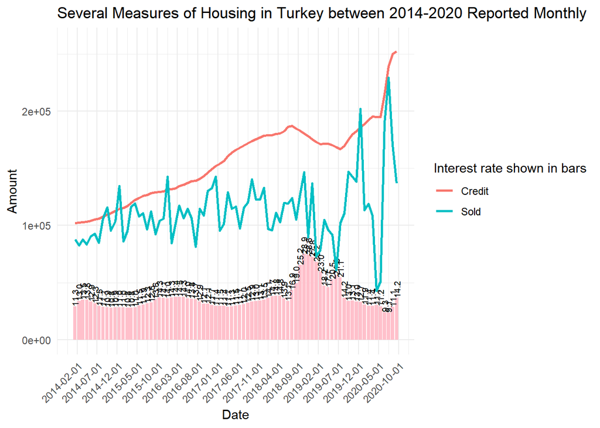

When the plot is examined, it can be seen that there has been volatility in number of houses sold between 2014 and 2019. The numbers seem to change a lot without any obvious cyclic or seasonal pattern. In the same period, it can also be claimed that there is an increase in the amount of credits taken. It might be logical to relate this increasing trend to the general inflation in that period. The housing prices might have elevated and people in return might have applied for higher amount of loans. This is also a period where the interest rate upon housing credit changes between values of %10 and %14. From this period, it cannot be clearly understood that whether there is any relationship between these three measures since each measure seems to move in small amounts, there are not any kind of unexpected behavior. Because the time period is long enough, it can be stated that this is the normal situation of Turkish Housing Sector and in this state, these measures do not show any kind of trend with respect to one another. However, more elaborate analysis via different type of visualizations and correlation tests can still reveal a weak degree of relatedness in the upcoming parts.

Moving on, starting from 2019 the situation of the market seem to change a lot. In the last few months of 2018, there starts a continuous increase in the interest rate. Moreover, it is in the same period that the amount of credits taken start to decrease. It can be stated, with trivial knowledge of economy, that the sudden increase in the interest rate may have triggered a response in the amount of housing credits taken. Housing customers in this period probably took lower amount of credits or there were smaller number of people funding housing via credit. To answer this question, it might be a good idea to inspect the number of houses sold in the same period. In the last months of 2018, the number of houses sold have fluctuated a lot. However, it can be understood that the housing market have gone into a recession and was not able to come out of it immediately. So, it can be stated that the climbing interest rates have affected the amount of housing credits and number of houses sold. However, the number of houses sold seem to respond to interest rate slower than the response of amount of credits taken. The explanation of these situation with the reasons underlying can be explained by use of more advanced knowledge of economy so it will not be included in this study.

Continuing the analysis in 2019, it can be claimed that the interest rate applied on housing credits starts decreasing eventually. However, in the first half of this year, the number of houses sold and the amount of loans taken are still comparably below of their usual level. It is only when the interest rate falls below to %15, both credits and number of houses sold starts increasing again. This ratio can be seen very magical at first, however it should be noted that the change from prior levels to %15 is sudden and very gradual. Hence, there might be several reasons triggering the change in housing preferences. Some of these can be listed. First of all, this sudden decrease could have resulted in a shock on the customer side, alongside with speculations and fear of facing higher interest rates again people might have thought that it can be a suitable time to take credit and buy housing. Secondly, there might be one or several third variables that affect all the measures of interest together. These could be for example exchange rates or inflation rates. Due to the fact that there are a huge number of measures that are closely correlated with the state of economy, it is very much hard to explain whether a relationship is a result of causation or just correlation.

Beyond the first half of 2019, the number of houses sold and the amount of housing credits taken have increased a lot in size, jumping to levels which are never seen before. Although the interest on the housing credit seem to be rather stable between normal levels, these movements in other measures can be explained by people postponing to buy house in late 2018 to July 2019. However, there are not much data points to test this claim as the market have been hit hard by the ongoing pandemic in 2020. The decreasing number of houses sold accompanied by rather stagnant amount of credits taken can be easily linked to the lockdowns and general downfall of economy in spring 2020. After that, by imposing a comparably small rate of interest on credit, the authorities seem to manage reviving the housing market resulting in an increase in credits taken. However, September 2020 shows a relatively different situation, though it would not be suitable to comment on this since it is not known whether this is a one-time thing or a new trend.

To inspect for relation between measures yearly boxplots can be visualized,

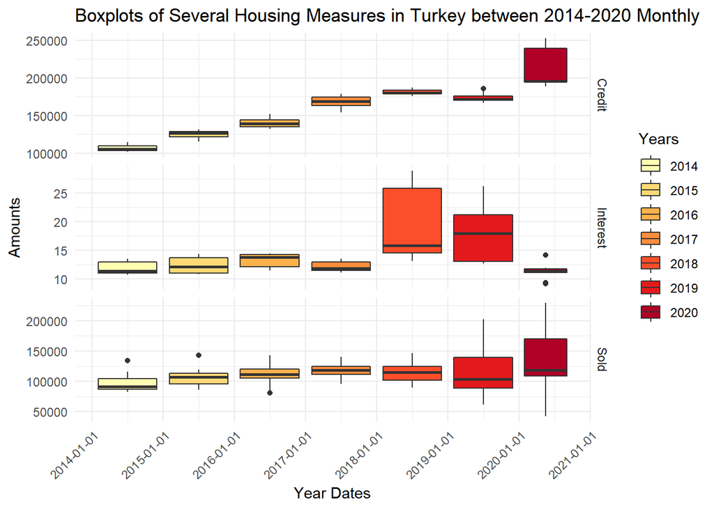

From the boxplots, it can be seen that the measures monthly total amounts of housing credit taken and the monthly total number of houses sold do not bear much variance over 2014-2018. In fact, although there is a permanent increasing pattern in amount of housing credits the monthly observations within a year are very close to each other. The amount of hoses sold however does not seem to be increasing or decreasing over time.

Though the monthly observations of interest rate seem to be separated to comparably wider intervals, the reader should keep in mind that the scales of the three measures are different from each other. As of the year 2018 however, the situation of interest rate upon housing credit have changed. The monthly reported values are scattered in a wider interval that year. The fact that there is not any sign of unexpected behavior or observation in housing credits or number of houses sold in 2018 might support the thesis that those measures are affected by the change in interest rate after some time. Moreover, the boxplot of 2019 interest rates also point a highly volatile period. By looking at the more-widely-scattered sold house numbers and the sudden decrease in observed amounts of housing credit in 2019, it could also be suggested that those two measures might have affected by the persistent high interest rates. Although both of these thesis are possible, again it should be noted that there are probably many other factors related to economy that are triggering change or volatility in some or all of the measures.

In year 2020 there is a completely different scenario. Interest rates imposed on housing credits are lower than ever. Nevertheless, there is still high volatility in number of houses sold accompanied by an ever large variability in amount of housing credits taken. This situation may lead to the conclusion that there are fluctuations in the housing market that are not potentially caused by the rate of interest. Still, these are several assumptions and it should be taken into account that because of their nature, boxplots are inadequate in terms of revealing any causation that have took place within a relatively short range of time. To be clearer, it is not understandable the relative movements and responses of measures with respect one another other occurring in a year.

## Scatter Plots and Normality Assumptions

Before moving on with correlation tests that will yield numeric and statistical data, one last visualization should be useful. In fact, this visualization will be an introduction to the correlation tests since it will be consisting of combined pairs of measures, their scatter plots and correlation coefficients.

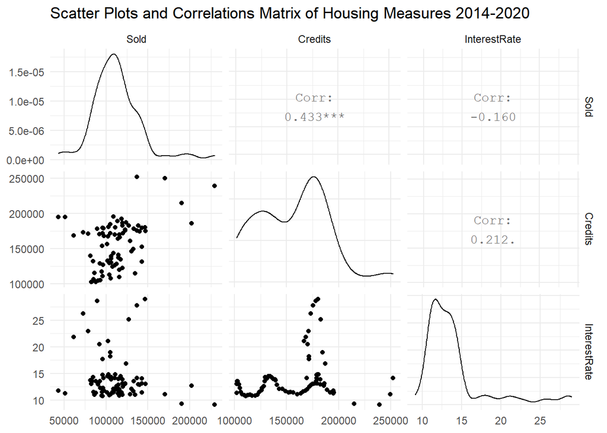

When the results are examined, at the diagonals it can be seen that the number of houses sold and the interest rate on the housing credit seems to be coming from a somewhat normal distribution over time, however, with several extremely high values occuring. Though the amount of credits taken cannot be fitted into a normal distribution as the aim of this study is analyzing the relations, this fact will be omitted. With the scatter plot and correlation results of number of houses sold to amount of credits taken it can be seen that there is a linear relationship between the two measures.

If the scatter plot of number of houses sold to the interest applied on the housing credit is inspected, it can be understood that there is not much correlation between the two measures. However, at the low rates of interest the observations of number of houses sold is much more scattered. This situation have arised probably because there was a relatively short range of time during which the interest rates were high. If this trend would have continued instead, people probably would not be able to postpone buying a house so there would again occur a degree of variability eventually. The comments on the correlation coefficient will be provided in the upcoming sections.

Lastly, the scatter plot of housing credits taken versus interest rates applied on the credit shows a very unique pattern. There seems to be certain observations that are occuring only together. Nevertheless, the analysis of such a behavior would require more advanced knowledge of statistics. Furthermore, it can mentioned that just like the previously examined scatter plot, with the high interest rates, the variance of the amount of credit taken certainly reduces. This could be due to the previously mentioned fact.

## Correlation Analyses

After these visualizations, running some correlation tests may yield more specific, although less detailed, explanations of the relations between the selected measures. As a first step, it would be sensible to apply correlation tests on the whole data points together. Keeping this in mind, in the upcoming three correlation test results combinations of the selected measures over the years 2014-2020 as one sample will be analyzed. Once these are calculated, it should be useful to inspect the correlations that are sampled using one or few several years and discussing any extreme or unforeseen result.

As it is generally known that a lot of people are funding the house they buy via housing credit, the correlation between number of houses sold and amount of housing credits taken is chosen as the first assumption to be tested. It should be noted here that, although the reader could trivially infer that the measures should be related, it requires a more advanced knowledge of economy and housing sector to guess the extent of this correlation.

```
## [1] "Correlation Test between Number of Houses Sold and Amount of Housing Credits over 2014-2020"
```

```
##
##  Pearson's product-moment correlation
##
## data:  amountSold$Amount and creditsTaken$Amount
## t = 4.2749, df = 79, p-value = 5.301e-05
## alternative hypothesis: true correlation is not equal to 0
## 95 percent confidence interval:
##  0.2375734 0.5954354
## sample estimates:
##       cor
## 0.4334386
```

Secondly, it is also easy to assume that the amount of credits taken is affected by the level of interest rate applied. It should be suspected by many people that the correlation between these two measures might be negative. However, looking at visualizations of these measures this link between the two measures is somewhat missing in the period 2014-2018. If a correlation test is carried out,

```
## [1] "Correlation Test between Amount of Housing Credits and the Interest Rate on Them over 2014-2020"
```

```
##
##  Pearson's product-moment correlation
##
## data:  creditsTaken$Amount and interestonCredit$Amount
## t = 1.9281, df = 79, p-value = 0.05744
## alternative hypothesis: true correlation is not equal to 0
## 95 percent confidence interval:
##  -0.006664078  0.411304445
## sample estimates:
##       cor
## 0.2119938
```

The estimated correlation coefficient is, indeed very surprisingly, positive. Nevertheless, it should be taken into account that the p-value is not as small as desired, so this result may only be statistically significant in a 0,1 level of confidence. Regarding the positive correlation, in the long run the effect of inflation on the amounts of credit taken in TRY might have caused this measure to increase, although in a lower amount, while the interest rate imposed on the credit increases. Again, with the use of inflation on the amount of credits taken, more comprehensive, and hopefully less surprising, results should be obtained.

Last but not at least, the indirect assumption of the existent relation between number of houses sold and the rate of interest applied on the housing credits can be tested. It is obvious that there is a third variable that is linked to both number of housing sold and interest rates on credit. Deriving from this and the previous assumptions, it might be claimed that the number of houses sold in a period can be negatively correlated to the interest rates imposed on the housing credits. Furthermore, with the exclusion of amount of housing credits taken the effect of inflation rate can no longer be a misleading factor here.

```
## [1] "Correlation Test between Number of Houses Sold and the Interest Rate on Housing Credit over 2014-2020"
```

```
##
##  Pearson's product-moment correlation
##
## data:  amountSold$Amount and interestonCredit$Amount
## t = -1.4376, df = 79, p-value = 0.1545
## alternative hypothesis: true correlation is not equal to 0
## 95 percent confidence interval:
##  -0.36528282  0.06080068
## sample estimates:
##        cor
## -0.1596685
```

Looking at the results of the test, there seems to be a weakly negative correlation between to measures. However, the p-value is much higher than needed so the hypothesis of no correlation cannot be readily rejected. Furthermore, it can be argued that buying preferences are usually subject to speculations and other subjective judgements. Due to that fact, the correlation between the two measures of interest may not be as strong and definite as expected.

```
## [1] "Yearly Conducted Correlation Tests between Number of Houses Sold and Amount of Housing Credits"
```

```
##   Year       Cor         pval
## 2 2014 0.8421281 0.0005887674
## 3 2015 0.4278523 0.1652944419
## 4 2016 0.7604396 0.0040886247
## 5 2017 0.6688858 0.0173854077
## 6 2018 0.1343797 0.6771340410
## 7 2019 0.8329275 0.0007688635
## 8 2020 0.6571664 0.0544472718
```

If we look at the yearly conducted correlation tests, it can be seen that for most of the years the amount of housing credits taken and the number of houses sold are strongly positively correlated. In few years, the correlation seems to be weak with high p-values. This indicates that, in some years there are no correlation. These results are surprising and might be the subject of a more advanced analysis making use of economy and related disciplines’ knowledge.

```
## [1] "Yearly Conducted Correlation Tests between Amount of Housing Credits and the Interest Rate on Them"
```

```
##   Year         Cor         pval
## 2 2014 -0.74705743 5.235262e-03
## 3 2015  0.89091319 1.010348e-04
## 4 2016 -0.96074582 6.871514e-07
## 5 2017  0.89445543 8.619102e-05
## 6 2018 -0.40920178 1.865404e-01
## 7 2019 -0.64270386 2.419329e-02
## 8 2020  0.05925474 8.796399e-01
```

```
## [1] "Yearly Conducted Correlation Tests between Number of Houses Sold and the Interest Rate on Housing Credit"
```

```
##   Year        Cor         pval
## 2 2014 -0.6182775 0.0321212027
## 3 2015  0.2180671 0.4959527908
## 4 2016 -0.6986802 0.0114786460
## 5 2017  0.5882242 0.0442428316
## 6 2018  0.4149346 0.1798383990
## 7 2019 -0.8362605 0.0006993039
## 8 2020 -0.5146855 0.1562534984
```

# Key Findings

Regarding all these analyses and conclusions, it is important to state that this report lacks the necessary amount of economical and sectoral knowledge. Most of the insights claimed are merely assumptions that are derived by pure visualizations along with basic correlation analysis. Incorporating more advanced information of the related fields may yield more intricate and statistically significant findings.

# References

[EVDS Web Site](https://evds2.tcmb.gov.tr/) • [R data.table Cheat Sheet](https://s3.amazonaws.com/assets.datacamp.com/blog_assets/datatable_Cheat_Sheet_R.pdf) • [R lubridate Cheat Sheet](https://evoldyn.gitlab.io/evomics-2018/ref-sheets/R_lubridate.pdf) • [Data Visualization](http://www.sthda.com/english/) • [Other Questions](https://stackoverflow.com/)

# Appendices

[Here](https://bu-ie-360.github.io/fall20-nilufercetin/files/HMW2.Rmd) the RMD File including the code chunks can be found.